## SEURAT WRAPPER TO REPORT SIGNIFICANT MARKERS AND REACTOME PATHWAYS

A new Seurat user is generally interested to run the single cell pipeline with less effort, quickly look at the expressed markers in different clusters and identify the pathways of interest within each cluster. This repository is a simple R package that has 4 functions:

[1]. SeuratPreprocess Function to convert Counts Data to Normalized and Scaled Seurat object for highly variable genes.

[2]. SeuratLowDim Function to convert Scaled Seurat Object from [1] to object that has clusters identified and data transformed to visualize in 2d (ie, PCA followed by t-SNE and UMAP).

[3]. SeuratMarkers Function to convert seurat object to all markers list, along with significant markers (based on minimum percent of cells in the cluster).

[4]. ReactomeData Function to convert seurat object to get the pathways identified using ReactomeGSA R package.

```r
library(Seurat)
library(ReactomeGSA)
library(scReport)
```

```r
# Loading sample counts data (Mouse cell atlas)
mca.matrix <- readRDS(file = "data/MCA_merged_mat.rds")
mca.metadata <- read.csv(file = "data/MCA_All-batch-removed-assignments.csv", row.names = 1)
mca.matrix.10K <- mca.matrix[,1:1000]
```

## [1]. Function to convert Counts Data to Normalized and Scaled Seurat object for highly variable genes.

## [2]. Function to convert Scaled Seurat Object from [1] to object that has clusters identified and data transformed to visualize in 2d (ie, PCA followed by t-SNE and UMAP).

```r
scaled_seurat_object <- SeuratPreprocess(mca.matrix.10K)
```

```
## Normalizing layer: counts
```

```
## Finding variable features for layer counts
```

```r
low_dim_object <- SeuratLowDim(scaled_seurat_object)
```

```
## PC_ 1
## Positive:  Gsta4, Ly6d, Wfdc2, Gstm1, Krt7
## Negative:  Sparc, Dcn, Col3a1, Col1a2, Serpinh1
## PC_ 2
## Positive:  Adh1, Gsn, Clec3b, Fbln1, Pi16
## Negative:  Srgn, Cd74, H2-Aa, H2-Eb1, H2-Ab1
## PC_ 3
## Positive:  H2-Eb1, Ctss, H2-Aa, Tyrobp, H2-Ab1
## Negative:  Esam, Egfl7, Emcn, Ecscr, Plvap
## PC_ 4
## Positive:  Cd34, Clec3b, Jam2, Thbd, Ecscr
## Negative:  Myl9, Acta2, Tagln, Tpm2, Tpm1
## PC_ 5
## Positive:  Fos, Atf3, Trf, Id2, Id1
## Negative:  Car3, Tnc, Cxcl14, Rbp4, Dkk2
```

```
## Modularity Optimizer version 1.3.0 by Ludo Waltman and Nees Jan van Eck
##
## Number of nodes: 999
## Number of edges: 27984
##
## Running Louvain algorithm...
## Maximum modularity in 10 random starts: 0.6380
## Number of communities: 17
## Elapsed time: 0 seconds
```

## [4]. Next, we use Reactome GSA R package to identify the pathways of interest using the cluster information of Seurat object.

```r
Reactome_pathways_object <- ReactomeData(low_dim_object)
```

```
## Converting expression data to string... (This may take a moment)
```

```
## Conversion complete
```

```
## Compressing request data...
```

```
## Reactome Analysis submitted succesfully
```

## Here is a quick glimpse of the output objects and tables outputted.

```r
scaled_seurat_object
```

```
## An object of class Seurat
## 15083 features across 999 samples within 1 assay
## Active assay: RNA (15083 features, 2000 variable features)
##  3 layers present: counts, data, scale.data
```

```r
low_dim_object
```

```
## An object of class Seurat
## 15083 features across 999 samples within 1 assay
## Active assay: RNA (15083 features, 2000 variable features)
##  3 layers present: counts, data, scale.data
##  3 dimensional reductions calculated: pca, tsne, umap
```

```r
Reactome_pathways_object[1]
```

```
## [[1]]
## ReactomeAnalysisResult object
##   Reactome Release: 88
##   Results:
##   - Seurat:
##     1827 pathways
##     8080 fold changes for genes
##   No Reactome visualizations available
```

```r
Reactome_pathways_object[3]
```

[output not shown]

[output cut: 3602 more lines]

[output not shown]

Pathways of interest:

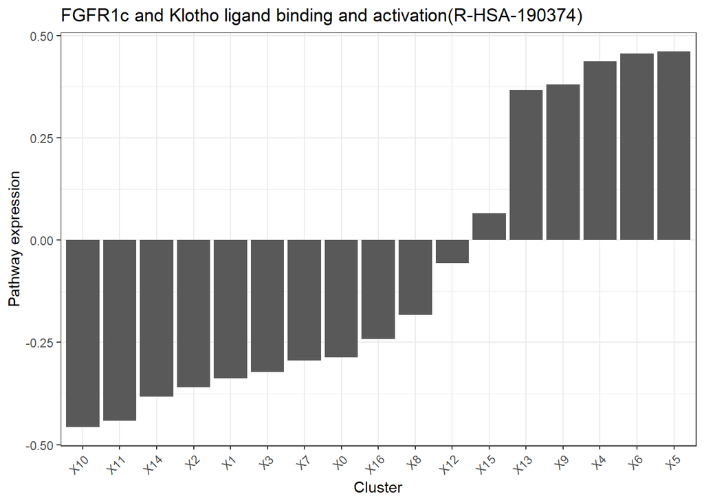

```r
plot_gsva_pathway(Reactome_pathways_object[[1]], pathway_id = rownames(Reactome_pathways_object[[3]])[1])
```

Same pathways showed as a heatmap:

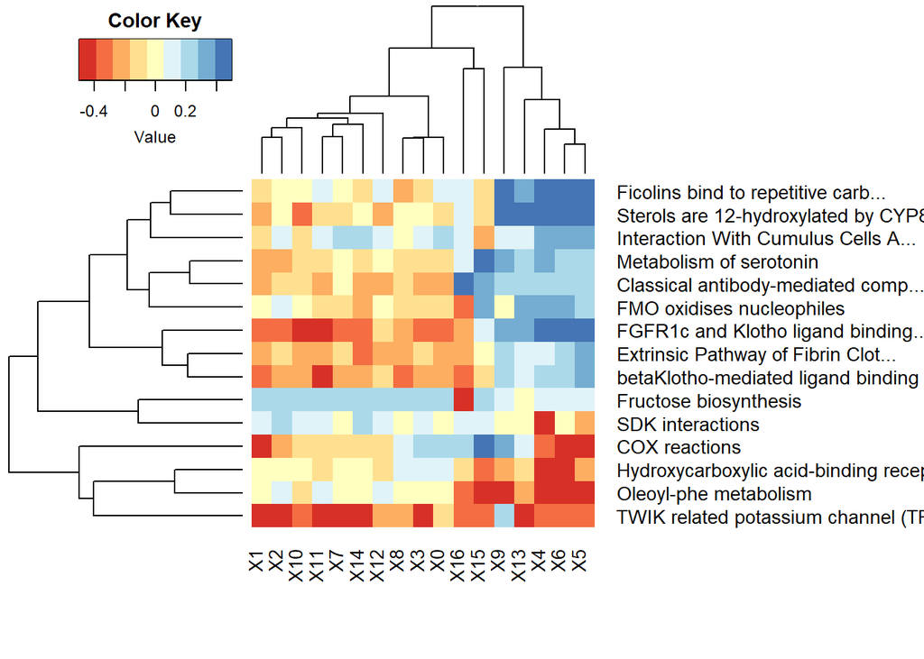

```r
plot_gsva_heatmap(Reactome_pathways_object[[1]], max_pathways = 15)
```

Relevant pathways based on user’s list:

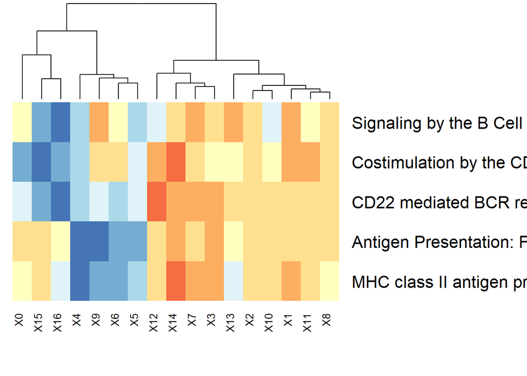

```r
relevant_pathways <- c("R-HSA-983170", "R-HSA-388841", "R-HSA-2132295", "R-HSA-983705", "R-HSA-5690714")
plot_gsva_heatmap(Reactome_pathways_object[[1]],
                  pathway_ids = relevant_pathways,
                  dendrogram = "col",
                  scale = "row", # scale for each pathway
                  key = FALSE,
                  lwid=c(0.1,4))
```